# Ejercicio 7

## David Montero Loaiza

### Problema 1

Escribe una función que tenga como input un vector x con valores distribuidos uniformemente, y unos parámetros a, b, m y n; y que devuelva como output una matriz cuya primera columna sea y = a + b x más un término estocástico sacado de una gaussiana con sigma = c + d x^2; y la segunda columna el error sigma = m + n x^2.

```r
generate_y_sigmas = function(x,a,b,m,n){

  # SIGMA
  sigma = m + n * x^2

  # GAUSSIANA
  y = a + b * x + rnorm(x,0,sigma)

  # DATA FRAME
  df = data.frame("y" = y,"sigma" = sigma)

  # RETORNAR DATA FRAME
  return(df)

}
```

### Problema 2

Escribe otra función que haga lo mismo que la anterior pero con un parámetro más “c” de tal forma que haga lo mismo pero con un modelo y = a + b x + c x^2.

```r
generate_y_sigmas_v2 = function(x,a,b,c,m,n){

  # SIGMA
  sigma = m + n * x^2

  # GAUSSIANA
  y = a + b * x + c * x^2 + rnorm(x,0,sigma)

  # DATA FRAME
  df = data.frame("y" = y,"sigma" = sigma)

  # RETORNAR DATA FRAME
  return(df)

}
```

### Problema 3

Usando como valores a = 1, b = 2, m = 0.1 y n = 0.04 para el modelo de la primera función: calcula los parámetros para las que el likelihood es máximo asumiendo un modelo con dos parámetros y = a + b x. Calcula el valor del chi2 y calcula el nivel de confianza con el que rechazaríamos este ajuste.

```r
generate_X = function(x,gpoly){

  # LA MATRIZ SE INICIA CON 1S
  X = rep(1,length(x))

  # SE AGREGAN LOS VALORES DE X ELEVADOS A CADA GRADO
  for(i in 1:gpoly){

    # SE ADJUNTAN LOS VALORES A LA MATRIZ
    X = cbind(X,x^i)

  }

  # SE RETORNA LA MATRIZ
  return(X)

}

maxLike = function(x,y,sigma,gpoly){

  # CREAR MATRIZ X
  X = generate_X(x,gpoly)

  # COVARIANZA Y
  covY = diag(sigma^2)

  # MINIMIZAR ML
  param = solve(t(X) %*% solve(covY) %*% X) %*% (t(X) %*% solve(covY)) %*% y

  # RETORNAR PARAMETROS
  return(param)

}

chiSquared = function(x,theta,y,sigma,gpoly){

  # CREAR MATRIZ X
  X = generate_X(x,gpoly)

  # CALCULAR Z
  Z = (y - X %*% theta) / sigma

  # RETORNAR CHI2
  return(sum(Z^2))

}
```

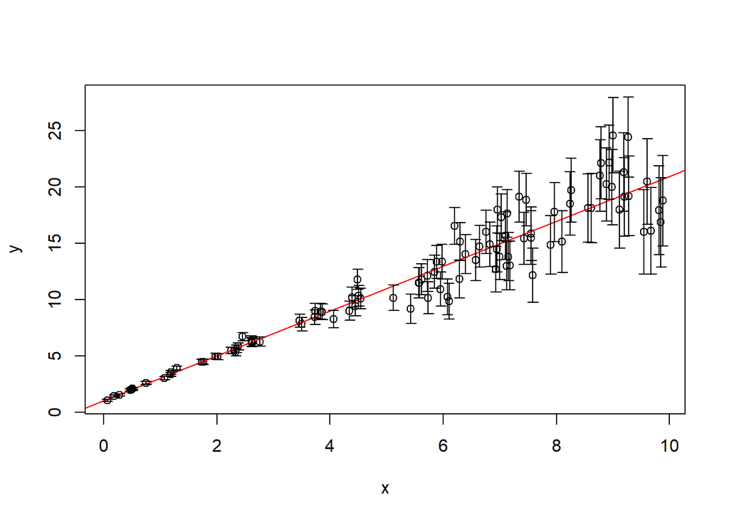

```r
# TAMANO DE X
N = 100

# VECTOR X
x = runif(N,0,10)

# PARAMETROS
a = 1
b = 2
m = 0.1
n = 0.04

# GRADO DEL POLINOMIO
g = 1

# NUMERO DE PARAMETROS
M = g + 1

# VECTOR Y Y SIGMA
df = generate_y_sigmas(x,a,b,m,n)
y = df$y
sig = df$sigma

# PARAMETROS
theta = maxLike(x,y,sig,gpoly = g)

# GRAFICA X Y
plot(x,y,ylim = c(min(y - sig),max(y + sig)))
abline(theta[1],theta[2],col = "red") # RECTA DE AJUSTE
arrows(x,y - sig,x,y + sig,length = 0.05,angle = 90,code = 3) # ERRORES
```

```r
# CHI2
chi2 = chiSquared(x,theta,y,sig,g)

# CONFIDENCE LEVEL
cl = pchisq(chi2,N - M) * 100

# RESPUESTA
sprintf("Chi2 = %f, Rechazamos H0 con un %f%% de confianza",chi2,cl)
```

```
## [1] "Chi2 = 78.852698, Rechazamos H0 con un 7.779764% de confianza"
```

### Problema 4

Repite el paso anterior con el mismo modelo pero usando la segunda función. c = 0.01.

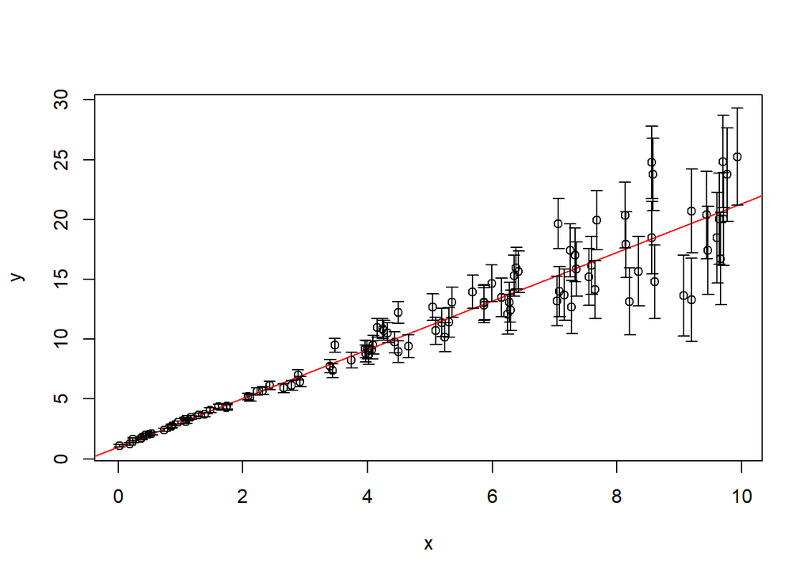

```r
# TAMANO DE X
N = 100

# VECTOR X
x = runif(N,0,10)

# PARAMETROS
a = 1
b = 2
c = 0.01
m = 0.1
n = 0.04

# GRADO DEL POLINOMIO
g = 1

# NUMERO DE PARAMETROS
M = g + 1

# VECTOR Y Y SIGMA
df = generate_y_sigmas_v2(x,a,b,c,m,n)
y = df$y
sig = df$sigma

# PARAMETROS
theta = maxLike(x,y,sig,gpoly = g)

# GRAFICA X Y
plot(x,y,ylim = c(min(y - sig),max(y + sig)))
abline(theta[1],theta[2],col = "red") # RECTA DE AJUSTE
arrows(x,y - sig,x,y + sig,length = 0.05,angle = 90,code = 3) # ERRORES
```

```r
# CHI2
chi2 = chiSquared(x,theta,y,sig,g)

# CONFIDENCE LEVEL
cl = pchisq(chi2,N - M) * 100

# RESPUESTA
sprintf("Chi2 = %f, Rechazamos H0 con un %f%% de confianza",chi2,cl)
```

```
## [1] "Chi2 = 90.240354, Rechazamos H0 con un 30.096023% de confianza"
```

### Problema 5

```r
# TAMANO DE X
N = 100

# VECTOR X
x = runif(N,0,10)

# PARAMETROS
a = 1
b = 2
c = 0.01
m = 0.1
n = 0.04

# GRADO DEL POLINOMIO
g = 1

# NUMERO DE PARAMETROS
M = g + 1

# VECTOR Y Y SIGMA
df = generate_y_sigmas_v2(x,a,b,c,m,n)
y = df$y
sig = df$sigma

# CHI2 PARA POLINOMIO GRADO 1
chi2poly1 = chiSquared(x,maxLike(x,y,sig,gpoly = 1),y,sig,gpoly = 1)

# CHI2 PARA POLINOMIO GRADO 2
chi2poly2 = chiSquared(x,maxLike(x,y,sig,gpoly = 2),y,sig,gpoly = 2)

# q
q = 2 * log(chi2poly1/chi2poly2)

# CL
cl = (1 - pchisq(q,1)) * 100

# RESPUESTA
sprintf("Chi2 = %f, Aceptamos H0 con un %f%% de confianza",chi2,cl)
```

```
## [1] "Chi2 = 90.240354, Aceptamos H0 con un 92.567617% de confianza"
```